[figure not shown]

# Problem Set 4 Notebook 2

## Notebook 2: Image Classification (5 points total)

## Instructions

Problem set 4 consists of three notebooks:

```
ps4_nb1.ipynb
ps4_nb2.ipynb
ps4_nb3.ipynb
```

### Due Date

- 23.FEB.2022 before 23:59:59 (CET)

### Instructor

- Prof. Dr. Gregory Wheeler (`g.wheeler@fs.de`)

### Declare your collaborators

You may work alone or in a group. The maximum group size is 4 people total.

If you work in a group, use the next cell to enter the list of names (first, last) of your collaborators. Do not include yourself.

```
# Example
COLLABORATORS = ['Stu Dent', 'May Bee', 'Ki Val Storr']
```

You should also familiarize yourself with the collaboration policy on the course Canvas page.

```python
# Be sure your names are strings
COLLABORATORS = ['Sophie Merl', 'Nicolas Kepper']
```

# The Importance of Image Classification Problems

The most important breakthroughs in machine learning in the last decade stem from advances made in two closely related fields, namely *computer vision* and *image processing*. Many of the innovations in AI that are in the news come from clever reformulations of a variety of prediction problems into the form of a **perception problem**. End-to-end deep learning architectures are applied to an expanding range of problems, from language translation, speech recognition, speech-to-text transcription, sound identification and sound isolation, as well as a wide variety of computer vision problems including facial recognition, object detection, segmentation, and behavioral prediction. Autonomous vehicles are an amalgamation of these techniques. And the list of applications is growing.

This is why understanding how image classification systems work is fundamental to understanding how deep learning works.

To begin to get a sense of the power of these techniques, consider this demonstration of a model called [LeNet5](http://yann.lecun.com/exdb/publis/pdf/lecun-01a.pdf), from 1998, due to Yann LeCun, Yoshua Bengio and collaborators then at AT&T Labs.

[figure not shown]

Images of handwritten digits, from 0 to 9, are moved from left to right across the "field of vision" of the computer, which is determined by a camera hooked up to a computer. The images are converted in real-time to a numerical array of greyscale pixel-values. That numerical representation of the frame-by-frame field of vision is then fed into the first layer of a trained (convolutional) neural network, which feeds those numerical input values forward through the network, one hidden layer after another, until the last layer predicts which category the input image most likely belongs to from the 10 + 1 possible categories. The eleventh category, [?], denotes a state in which none of the nodes in the final layer has a strong enough signal to dominate the others. The answer generated by the algorithm is then displayed in red, above the image.

A remarkable feature of this relatively simple network is how robust the classification is to distortions of the input, from ambiguous inputs, to noise, to invertible transformations of the input. Below are demonstrations of each, resptectively, courtesy of [Yann LeCun](http://yann.lecun.com/).

| 12 to 4 to 21 | Robust to noise | Robust to transformations |
| --- | --- | --- |

The resliance you see is a distinguishing feature of [convolutional neural networks](https://towardsdatascience.com/a-comprehensive-guide-to-convolutional-neural-networks-the-eli5-way-3bd2b1164a53) (CNNs), which are an extension of the basic feed-forward artificial neural networks (ANNs) we studied in class. You will learn about CNNs in later courses.

LeNet 5 was limited to recognizing digits; it did not work well on images, nor on video, nor sound. Nevertheless, modern deep learning systems are direct descendants of LeNet 5. For their pioneering work, LeCunn and Bengio, together with Geoffrey Hinton, who co-developed the **backpropagation algorithm** in the 1980s, received the [Turing Award in 2018](https://awards.acm.org/about/2018-turing), the 'Nobel Prize' of computer science.

Modern machine learning libraries, such as sklearn and keras/tensor flow, are vastly more powerful than LeNet 5 and capable of handling images, video, sound, as well as text and speech -- given sufficiently large data sets and adequate computational resources. Nevertheless, building a model to recognize hand-written digits is a very good introduction to the fundamental building blocks of contemporary deep learning models.

# Build a Hand-written Digit Classifier

## I. Load basic libraries.

```python
import numpy as np
np.random.seed(716)
import matplotlib.pyplot as plt
```

## II. Construct a Random Forest Classifier

Random Forests are a very powerful yet easy model to try out. Problem set 3 may have suggested otherwise, and that was partly the point: there is no free lunch. No single model is best for every problem. That said, I think you will be happier with the performance of random forests on this problem.

You will build a **random forest classifier** using the built-in, low-resolution MNST digit recognition data set. The following code should be put into the next cell. Note the variable name `digits` we will use.

```
from sklearn.datasets import load_digits
digits = load_digits()
digits.keys()
```

Be sure you understand what this code is doing. For instance, check the data type of `digits`. Although you won't need to know exactly what a bunch is, it is nevertheless helpful to understand that bunches are a particular kind of dictionary, and to recognize that you worked with dictionaries before in problem set 3. Hence, because bunches are a specific type of dictionary, the dictionary method `.keys()` returns the list of strings used as key values.

```python
from sklearn.datasets import load_digits
digits = load_digits()
digits.keys()
```

```
dict_keys(['data', 'target', 'frame', 'feature_names', 'target_names', 'images', 'DESCR'])
```

### - EDA

It is a good habit to inspect your data, and `digits.keys()` returns the dictionary key names:

[output not shown]

You can now look at the objects stored under each key. For instance, `digits['target_names']` returns the array of digit labels

```
array([0, 1, 2, 3, 4, 5, 6, 7, 8, 9])
```

The key `data` stores the 8x8 pixel images in greyscale we will use as input. Each image is represented as an np.array. For instance, `digits['data'][7]` is the array

```
array([ 0.,  0.,  7.,  8., 13., 16., 15.,  1.,  0.,  0.,  7.,  7.,  4.,
       11., 12.,  0.,  0.,  0.,  0.,  0.,  8., 13.,  1.,  0.,  0.,  4.,
        8.,  8., 15., 15.,  6.,  0.,  0.,  2., 11., 15., 15.,  4.,  0.,
        0.,  0.,  0.,  0., 16.,  5.,  0.,  0.,  0.,  0.,  0.,  9., 15.,
        1.,  0.,  0.,  0.,  0.,  0., 13.,  5.,  0.,  0.,  0.,  0.])
```

which encodes the grey-scale values for the 64 pixels of the 8x8 image of the hand-written numeral '7' appearing in the upper right corner of the plot, below.

### - Plot

The next step is to visualize your data. These three lines of code,

```
# initial visualization
fig = plt.figure(figsize= (5,5))
fig.subplots_adjust(left=0, right=1, bottom=0, top=1, hspace=0.05, wspace=0.05)
for i in range(64):
    ...
    ...
    ...
```

are the first three lines of 6 lines, total, used to produce the following image:

[figure not shown]

This plot used the `.imshow` and `.text` methods, called on `digits.images` and `digits.target`. The color map is `cmap = plt.cm.binary`, and `interpolation='nearest'` is used.

**Tip:** To turn off the x and y tick marks, use an empty list: **xticks=[]** and **yticks=[]**

Observe that your plot should include the `target` value in the upper left corner of each corresponding image.

Enter your code to plot in the following cell.

**Student's answer Score: 0.5 / 0.5 (Top)**

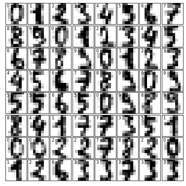

```python
# initial visualization
fig = plt.figure(figsize= (5,5))
fig.subplots_adjust(left=0, right=1, bottom=0, top=1, hspace=0.05, wspace=0.05)
for i in range(64):
    plt.subplot(8, 8, i+1, xticks=[], yticks=[])
    plt.imshow(digits.images[i], cmap=plt.cm.binary, interpolation='nearest')
    plt.text(0, 1, digits.target[i], size='small')
```

### - Import SKLearn Libraries; Fit and Evaluate a Random Forest Model

Build a random forest classifier, split the data into a training set and a test set, fit the model, and test on the test set $-$ *all in 4 lines of code*. Consult the [documentation](https://scikit-learn.org/stable/modules/generated/sklearn.ensemble.RandomForestClassifier.html) for sklearn random forests for how to fit and make predictions with your model.

```
from sklearn.ensemble import RandomForestClassifier
from sklearn.cross_validation import train_test_split
Xtrain, Xtest, ytrain, ytest = train_test_split(digits.data, digits.target, random_state = 10)

# build a forest of 1000 estimators with maximum tree depth of 4
rfc = RandomForestClassifier(max_depth = 4, n_estimators=1000)

# fit rfc to your training data
fit_rfc = # YOUR CODE HERE

# test on your test set
ypred = # YOUR CODE HERE
```

**Important:** To standardize grading, do not change the value assigned to the random state. Also the initial settings of max_depth and n_estimators should not be changed. You will change these values later in the assignment.

**Important:** Remember to remove any print statements you might add to the body of your functions.

Use the next cell to fit and evaluate your model.

**Student's answer(Top)**

```python
from sklearn.ensemble import RandomForestClassifier
from sklearn.model_selection import train_test_split, GridSearchCV

Xtrain, Xtest, ytrain, ytest = train_test_split(digits.data, digits.target, random_state = 10)
def initialModel():
    """A simple function to build build, fit, and evaluate
        your initial random forest model

    :rfc:     sklearn ensemble
        A random forest model with 1000 estimators with a max depth of 4
    :fit_rfc: sklearn ensemble
        The random forest model rfc fit to Xtrain and ytrain
    :ypred:   np n-dimensional array
        The predicted class labels given Xtest
    """
    rfc = RandomForestClassifier(max_depth = 4, n_estimators=1000)
    fit_rfc = rfc.fit(Xtrain, ytrain)
    ypred = fit_rfc.predict(Xtest)
    return rfc, fit_rfc, ypred
```

**Grade cell: `cell-2d5878ec2fd21c88` Score: 0.5 / 0.5 (Top)**

```python
# Test cell
rfc, fit_rfc, ypred = initialModel()
### HIDDEN TEST
if len(ypred) == 450:
    assert True
else:
    if len(ypred) == 1347:
        raise AssertionError("Pred should be evaluated on Xtest, not Xtrain")
    else:
        raise AssertionError("Pred should be evaluated on Xtest")
```

The next cell gives the basic performance metrics of your model:

```
from sklearn import metrics
print(metrics.classification_report(ypred, ytest))
```

Your code should produce a matrix with *approximately* these values

[figure not shown]

You may see values for precision, recall, f1, or support sets that vary slightly from those in this example table.

```python
from sklearn import metrics
print(metrics.classification_report(ypred, ytest))
```

```
              precision    recall  f1-score   support

           0       0.98      0.98      0.98        46
           1       0.86      0.93      0.89        41
           2       0.98      0.86      0.92        51
           3       0.94      0.94      0.94        48
           4       0.93      0.90      0.91        41
           5       0.95      0.91      0.93        43
           6       1.00      1.00      1.00        47
           7       0.94      0.86      0.90        51
           8       0.81      0.95      0.88        37
           9       0.82      0.89      0.85        45

    accuracy                           0.92       450
   macro avg       0.92      0.92      0.92       450
weighted avg       0.92      0.92      0.92       450
```

## III. Tuning your model

Your classifier is performing pretty well on your test set. Can you do better? Let's see if we can tune parameters to improve your scores on a cross-validation set.

However, as you may have noticed, random forests are significantly more expensive, computationally, than the linear models we have worked with earlier. So, you will need to manage your computational resources wisely.

In the next answer block, you should finish the function `setMyGrid_1()`, which defines the dictionary `my_grid` of parameter values and an integer `num` to use in searching for optimal hyperparameters. Specifically, the template for `setMyGrid_1()` is:

```
# Define my_grid
my_grid = {'max_depth': [-1-, -2-, ..., -n-],
              'criterion': ['gini', 'entropy'], 'random_state': [10]}
num = -int-
```

where `my_grid` is a dictionary of parameters that includes:

- `'max_depth'`, whose key value is a list of integers, [-1-, -2-, ..., -n-], representing different candidate maximum tree depth values;
- `'criterion'`, whose value is a list of strings that name purity measures you can use. The two impurity measures you may use are `'gini'` and `'entropy'`;
- `'random_state'`, a list of integers, which sets the random seed or seeds used by the random forest algorithm for replication. You must use the random seed $10$, which is passed by the list `[10]`.

**Reminder:** In this exercise you must use **'random_state': [10]**.

For this first step, **no other hyperparameters** should be added to your grid search.

Finally, the variable

- `num`, an integer between 1 and 10 that specifies how many parallel processes are run to perform your grid search, from 1 (no parallelization) to 10 (maximum parallelization).

The rough idea behind `num` is this: parallel processing trades off between **faster processing** and **robustness** of results, where no parallel processing incurs the **highest computational cost**, which means slower processing, for the **most robust estimates**. Introducing parallel processes gains efficiency, but does so at the *possible* expense of producing less robust results. The AI Servers are much more powerful than your desktop computers, but there are many people using the cluster, too. You can experiment to see whether you can take advantage of parallel processing without sacrificing robustness within the precision the assignment calls for.

You will have a **time limit** to perform your grid search, to be explained in the section titled "**Managing computational resources**", next. Yes, this time gate can be circumvented. However, keep in mind that if you do and crash the server for your classmates by hogging computational resources, you will have some explaining to do.

**Student's answer(Top)**

```python
def setMyGrid_1():
    """A function to set list of estimators and grid parameters"""
    my_grid = {'max_depth': [10],
              'criterion': ['gini', 'entropy'], 'random_state': [10]}
    num = 10
    return num, my_grid
```

### Managing computational resources

Until now you have enjoyed the luxury of not worrying about limits on computational resources. But for real machine learning problems, managing limited computational resources is often an unavoidable and serious concern. You are sharing a cluster with many other people. **So, you will likely run into the limits of the resources available to you to complete this assignment.** Therefore, in addition to shrewdly minimizing your own demands for computational power, you may also need to be strategic in *when* to use the server.

The next block of code is designed to help you find optimal parameters for your random forest and give you feedback on how much time your grid search is taking. Each search is limited to **90 seconds**, but keep in mind that your runtime may vary depending on the total load on the cluster.

### Step 1.

Define `my_grid` and `num`, then run the next cell. Adjust `my_grid` and `num` to find optimal values for (i) `max_depth` and (ii) `criterion` (choosing from either `'gini'` or `'entropy'`). Continue your search until you have a good idea where in this parameter space to focus your attention to get the best score in the next step, which will be printed for you.

The **best score** (i.e., mean cross-validation score) is computed by the `.best_score_` method for you. [See section 3.2.3.6](https://scikit-learn.org/stable/modules/grid_search.html#grid-search) of the SKLearn grid search documentation for a description. There you will also find instructions for how to introduce other metrics for evaluatiing your models -- which you would typically use in practice but *should not* be used for this assignment.

The next cell fits and evaluates by 3-fold (the default) cross-validation using [GridSearchCV](https://scikit-learn.org/0.16/modules/generated/sklearn.grid_search.GridSearchCV.html). Your parameter `num`, sets the number of jobs to run in parallel. The default is `n_jobs = 1`, that is, no parallelization.

**Tip:** Given the time limits, it is anticipated that you may need to go back to adjust `num` and the size and range of tree depths to arrive at reasonable parameters. Think of `num` as a precision knob: lower values **may** correspond to slow but precise, and higher values correspond to fast but less precise. Thus, once you settle on candidates for your optimal parameter settings, you should confirm these choices with num set to a more precise setting, for instance, **num = 1** . Once confirmed, it is then a good idea to set `num` to as high a level as possible -- that is to as high a level that preserves your results to the precision limits of the assignment. This will conserve computational resources and help you to pass through the second validation test necessary for submitting your assignment.

**Grade cell: `setMyGrid1-test1` Score: 0.5 / 0.5 (Top)**

```python
# Test cell
# Note: this cell has a timer limited to 90 seconds runtime.
num, my_grid = setMyGrid_1()
%run -i 'ps4_timed_grid_search.py'
```

```
Best Score:
 0.9777392262150627
Best Parameters using grid search:
 {'criterion': 'gini', 'max_depth': 10, 'random_state': 10}
Time taken in grid search:  9.84
```

**Grade cell: `setMyGrid1-test2` Score: 0.5 / 0.5 (Top)**

```python
# test cell
### BEGIN HIDDEN TESTS
precision_tst = 8
test_score = round(0.9777392262150627, precision_tst)
if round(cv_rfc.best_score_,precision_tst) == test_score:
    assert True
else:
    raise AssertionError("The best parameter score rounded to {0} places is {1}; your answer is: {2}".format(precision_tst,test_score,round(cv_rfc.best_score_,precision_tst) ))

del test_score
del precision_tst
### END HIDDEN TESTS
```

**Grade cell: `setMyGrid1-test3` Score: 0.5 / 0.5 (Top)**

```python
# test cell
### BEGIN HIDDEN TESTS
if cv_rfc.best_params_['max_depth'] == 10:
    assert True
else:
    raise AssertionError("The best maximum depth is 10, not {0}".format(cv_rfc.best_params_['max_depth']))
### END HIDDEN TESTS
```

**Grade cell: `cell-ef48086efd4bc58c` Score: 0.5 / 0.5 (Top)**

```python
# test cell
### BEGIN HIDDEN TESTS
if cv_rfc.best_params_['criterion'] == 'gini':
    assert True
else:
    raise AssertionError("The best purity measure is gini, not".format(cv_rfc.best_params_['criterion']))
### END HIDDEN TESTS
```

From Step 1 you now have parameters to use to evaluate your model, where in the template below `-1-` is an integer and `-2-` is the string `'entropy'` or `'gini'`:

```
rfc = RandomForestClassifier(max_depth = -1-, criterion = -2-, n_estimators=1000)
fit_rfc = rfc.fit(Xtrain, ytrain)
ypred = rfc.predict(Xtest)
```

Let's turn to the next step.

**Student's answer(Top)**

```python
def second_Model():
    """A simple function to build build, fit, and evaluate
        your second random forest model

    :rfc:     sklearn ensemble
        A random forest model with 1000 estimators with a max depth of 4
    :fit_rfc: sklearn ensemble
        The random forest model rfc fit to Xtrain and ytrain
    :ypred:   np n-dimensional array
        The predicted class labels given Xtest
    """

    rfc = RandomForestClassifier(max_depth = 10, criterion = 'gini', n_estimators=1000)
    fit_rfc = rfc.fit(Xtrain, ytrain)
    ypred = rfc.predict(Xtest)
    return rfc, fit_rfc, ypred
```

The next cell prints the performance report for your new predictions `ypred_2` from your newly tuned random forest model on the same test set as before, `ytest`. Just to be clear, the optimized parameters for `max_depth` and `criterion` that you selected from the average performance on $n$-fold cross-validation sets are the parameters `secondModel()` uses to evaluate the performance of your model so-parameterized on the test set `ytest`.

```python
# Run to generate a performance report
# Do not alter variable assignments made in this cell.
from sklearn.metrics import precision_score, recall_score, f1_score
_, _, ypred_2 = second_Model()
prec_2 = precision_score(ytest, ypred_2, average = 'macro')
recall_2 = recall_score(ytest, ypred_2, average = 'macro')
f1_2 = f1_score(ytest, ypred_2, average = 'macro')
print(metrics.classification_report(ypred_2, ytest))
print("\nYour Macro Average Precision Score is: \t{0}".format(prec_2))
print("Your Macro Average Recall Score is: \t{0}".format(recall_2))
print("Your Macro Average F1 Score is: \t{0}".format(f1_2))
```

```
              precision    recall  f1-score   support

           0       0.98      1.00      0.99        45
           1       0.98      0.96      0.97        45
           2       1.00      0.98      0.99        46
           3       0.96      0.96      0.96        48
           4       0.95      0.97      0.96        39
           5       1.00      0.93      0.96        44
           6       1.00      1.00      1.00        47
           7       1.00      0.94      0.97        50
           8       0.88      0.93      0.90        41
           9       0.92      1.00      0.96        45

    accuracy                           0.97       450
   macro avg       0.97      0.97      0.97       450
weighted avg       0.97      0.97      0.97       450


Your Macro Average Precision Score is: 	0.9665156182923946
Your Macro Average Recall Score is: 	0.9665955207342612
Your Macro Average F1 Score is: 	0.9660659523216408
```